# **Problem Statement**

# **Data Preprocessing**

## Converting images to grayscale

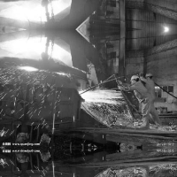

```python
# Converting the images from color to Grayscale
images_gray = []
for i in range(len(images)):
    img_gray = cv2.cvtColor(images[i], cv2.COLOR_BGR2GRAY)  # Convert to grayscale
    images_gray.append(img_gray)

# Display a sample grayscale image
n = 10  #  any valid index
cv2_imshow(images_gray[5])
```

### Splitting the dataset

- As we have less images in our dataset, we will only use 10% of our data for testing, 10% of our data for validation and 80% of our data for training.
- We are using the `train_test_split()` function from scikit-learn. Here, we split the dataset into three parts, train,test and validation.

```python
from sklearn.model_selection import train_test_split
X_train, X_temp, y_train, y_temp = train_test_split(np.array(images),labels , test_size = 0.2, random_state = 42,stratify = labels)
X_val, X_test, y_val, y_test = train_test_split(X_temp, y_temp, test_size = 0.5, random_state = 42,stratify = y_temp)
```

```python
print(X_train.shape,y_train.shape)
print(X_val.shape,y_val.shape)
print(X_test.shape,y_test.shape)
```

```
(504, 200, 200, 3) (504, 1)
(63, 200, 200, 3) (63, 1)
(64, 200, 200, 3) (64, 1)
```

- There are 504 colored images for training dataset (Shape 200 X 200 with each image having 3 channels)
- There are 63 colored images for validation dataset (Shape 200 X 200 with each image having 3 channels)
- There are 64 colored images for test dataset (Shape 200 X 200 with each image having 3 channels)

### Data Normalization

Since the **image pixel values range from 0-255**, our method of normalization here will be **scaling** - we shall **divide all the pixel values by 255 to standardize the images to have values between 0-1.**

```python
# Normalizing the image pixels
X_train_normalized = X_train.astype('float32')/255.0
X_val_normalized = X_val.astype('float32')/255.0
X_test_normalized = X_test.astype('float32')/255.0
```

# **Model Building**

## Model Evaluation Criterion

- With Helmet: Workers who are wearing helmet as 1.
- Without Helmet: Workers who are not wearing helmets as 0.

**Which case is important?**

- **False Positive (FP)**: Predicts With Helmet but in actual Without Helment - More Risk to serious injury
- **False Negative (FN)**: Predicts Without Helmet but in actual With Helmet - less impact as it leads to only warning but not serious injury

Based on the above scenario we have to reduce False Positives. To reduce FP we have to increase the Precision. As we know , Precision = True Positives/Total predicted positives) We will choose both accuracy and Precision as our metrics for comparision.

## Utility Functions

```python
# defining a function to compute different metrics to check performance of a classification model built using statsmodels
def model_performance_classification(model, predictors, target):
    """
    Function to compute different metrics to check classification model performance

    model: classifier
    predictors: independent variables
    target: dependent variable
    """

    # checking which probabilities are greater than threshold
    pred = model.predict(predictors).reshape(-1)>0.5

    target = target.to_numpy().reshape(-1)


    acc = accuracy_score(target, pred)  # to compute Accuracy
    recall = recall_score(target, pred, average='weighted')  # to compute Recall
    precision = precision_score(target, pred, average='weighted')  # to compute Precision
    f1 = f1_score(target, pred, average='weighted')  # to compute F1-score

    # creating a dataframe of metrics
    df_perf = pd.DataFrame({"Accuracy": acc, "Recall": recall, "Precision": precision, "F1 Score": f1,},index=[0],)

    return df_perf
```

```python
def plot_confusion_matrix(model,predictors,target,ml=False):
    """
    Function to plot the confusion matrix

    model: classifier
    predictors: independent variables
    target: dependent variable
    ml: To specify if the model used is an sklearn ML model or not (True means ML model)
    """

    # checking which probabilities are greater than threshold
    pred = model.predict(predictors).reshape(-1)>0.5

    target = target.to_numpy().reshape(-1)

    # Plotting the Confusion Matrix using confusion matrix() function which is also predefined tensorflow module
    confusion_matrix = tf.math.confusion_matrix(target,pred)
    f, ax = plt.subplots(figsize=(10, 8))
    sns.heatmap(
        confusion_matrix,
        annot=True,
        linewidths=.4,
        fmt="d",
        square=True,
        ax=ax
    )
    plt.show()
```

## Model 1: Simple Convolutional Neural Network (CNN)

Let's build a **CNN Model**.

The model has 2 main parts:

1. **The Feature Extraction layers** which are comprised of convolutional and pooling layers.
2. **The Fully Connected classification layers for prediction.**

```python
# Initializing Model
model_1 = Sequential()

# Convolutional layer 1
model_1.add(Conv2D(32, (3, 3), activation='relu', padding="same", input_shape=(200, 200, 3)))
model_1.add(MaxPooling2D((4, 4) , padding="same"))

# Convolutional layer 2
model_1.add(Conv2D(6, (3, 3), activation='relu', padding="same"))
model_1.add(MaxPooling2D(pool_size=(4, 4), padding='same'))


# Convolutional layer 3
model_1.add(Conv2D(4, (1, 1), activation='relu', padding="same"))

# Flatten and Dense Layers
model_1.add(Flatten())
model_1.add(Dense(4, activation='relu'))
#model_1.add(Dropout(rate=0.4))
model_1.add(Dense(1, activation='sigmoid'))

# Compile with Adam Optimizer
opt = Adam(learning_rate=0.001)
model_1.compile(optimizer=opt, loss='binary_crossentropy', metrics=["accuracy","Precision"])

# Print model summary
model_1.summary()
```

```
Model: "sequential"
```

```
┏━━━━━━━━━━━━━━━━━━━━━━━━━━━━━━━━━┳━━━━━━━━━━━━━━━━━━━━━━━━┳━━━━━━━━━━━━━━━┓
┃ Layer (type)                    ┃ Output Shape           ┃       Param # ┃
┡━━━━━━━━━━━━━━━━━━━━━━━━━━━━━━━━━╇━━━━━━━━━━━━━━━━━━━━━━━━╇━━━━━━━━━━━━━━━┩
│ conv2d (Conv2D)                 │ (None, 200, 200, 32)   │           896 │
├─────────────────────────────────┼────────────────────────┼───────────────┤
│ max_pooling2d (MaxPooling2D)    │ (None, 50, 50, 32)     │             0 │
├─────────────────────────────────┼────────────────────────┼───────────────┤
│ conv2d_1 (Conv2D)               │ (None, 50, 50, 6)      │         1,734 │
├─────────────────────────────────┼────────────────────────┼───────────────┤
│ max_pooling2d_1 (MaxPooling2D)  │ (None, 13, 13, 6)      │             0 │
├─────────────────────────────────┼────────────────────────┼───────────────┤
│ conv2d_2 (Conv2D)               │ (None, 13, 13, 4)      │            28 │
├─────────────────────────────────┼────────────────────────┼───────────────┤
│ flatten (Flatten)               │ (None, 676)            │             0 │
├─────────────────────────────────┼────────────────────────┼───────────────┤
│ dense (Dense)                   │ (None, 4)              │         2,708 │
├─────────────────────────────────┼────────────────────────┼───────────────┤
│ dense_1 (Dense)                 │ (None, 1)              │             5 │
└─────────────────────────────────┴────────────────────────┴───────────────┘
```

```
 Total params: 5,371 (20.98 KB)
```

```
 Trainable params: 5,371 (20.98 KB)
```

```
 Non-trainable params: 0 (0.00 B)
```

**Let us try to understand the parameters in the CNN layers:**

- **First Conv2D Layer**  
  The input shape to the Conv2D layer: (200,200,3)  
  The Size of the Filter: 3x3  
  The Number of Filters: 32  
  The Number of parameters: (3x3x3+1)x32 = 896  
  `(width of filter in current layer x height of filter in current layer x number of filters in previous layer + bias) x number of filters in current layer`
- **Max Pooling Layer**  
  Pooling has no trainable parameters, so the number of parameters: 0
- **Flatten**  
  It does not have any trainable parameters, so the number of parameters: 0
- **Fully Connected Dense Layer**  
  Number of neurons: 4  
  Number of parameters: (4x676)+(1x4): 2708
- **Output Layer**  
  Number of neurons: 1  
  Number of parameters: (1x4)+(1x1)=5  
  ` Number of neurons in current layer x number of neurons in the previous layer

```python
history_1 = model_1.fit(X_train_normalized, y_train, epochs=10, batch_size=32, validation_data=(X_val_normalized, y_val),shuffle=True,verbose =1)
```

```
16/16 ━━━━━━━━━━━━━━━━━━━━ 5s 169ms/step - Precision: 0.5070 - accuracy: 0.4693 - loss: 0.6723 - val_Precision: 0.4921 - val_accuracy: 0.4921 - val_loss: 0.5923
16/16 ━━━━━━━━━━━━━━━━━━━━ 0s 25ms/step - Precision: 0.5519 - accuracy: 0.5689 - loss: 0.5447 - val_Precision: 0.5636 - val_accuracy: 0.6190 - val_loss: 0.4862
16/16 ━━━━━━━━━━━━━━━━━━━━ 0s 25ms/step - Precision: 0.7876 - accuracy: 0.8426 - loss: 0.3633 - val_Precision: 1.0000 - val_accuracy: 0.9683 - val_loss: 0.1220
16/16 ━━━━━━━━━━━━━━━━━━━━ 0s 23ms/step - Precision: 0.9854 - accuracy: 0.9794 - loss: 0.0944 - val_Precision: 1.0000 - val_accuracy: 1.0000 - val_loss: 0.0407
16/16 ━━━━━━━━━━━━━━━━━━━━ 0s 24ms/step - Precision: 0.9884 - accuracy: 0.9849 - loss: 0.0491 - val_Precision: 1.0000 - val_accuracy: 0.9524 - val_loss: 0.1065
16/16 ━━━━━━━━━━━━━━━━━━━━ 0s 25ms/step - Precision: 0.9916 - accuracy: 0.9946 - loss: 0.0304 - val_Precision: 1.0000 - val_accuracy: 0.9841 - val_loss: 0.0244
16/16 ━━━━━━━━━━━━━━━━━━━━ 1s 24ms/step - Precision: 0.9951 - accuracy: 0.9950 - loss: 0.0148 - val_Precision: 1.0000 - val_accuracy: 0.9841 - val_loss: 0.0421
16/16 ━━━━━━━━━━━━━━━━━━━━ 0s 24ms/step - Precision: 1.0000 - accuracy: 0.9975 - loss: 0.0175 - val_Precision: 1.0000 - val_accuracy: 0.9841 - val_loss: 0.0370
16/16 ━━━━━━━━━━━━━━━━━━━━ 0s 26ms/step - Precision: 1.0000 - accuracy: 0.9975 - loss: 0.0120 - val_Precision: 1.0000 - val_accuracy: 0.9841 - val_loss: 0.0356
16/16 ━━━━━━━━━━━━━━━━━━━━ 0s 24ms/step - Precision: 1.0000 - accuracy: 0.9975 - loss: 0.0114 - val_Precision: 1.0000 - val_accuracy: 0.9841 - val_loss: 0.0384
```

**Observation:** From the above it can be seen that the precison and accuracy values shows improvement and the loss is decreased. This looks good.

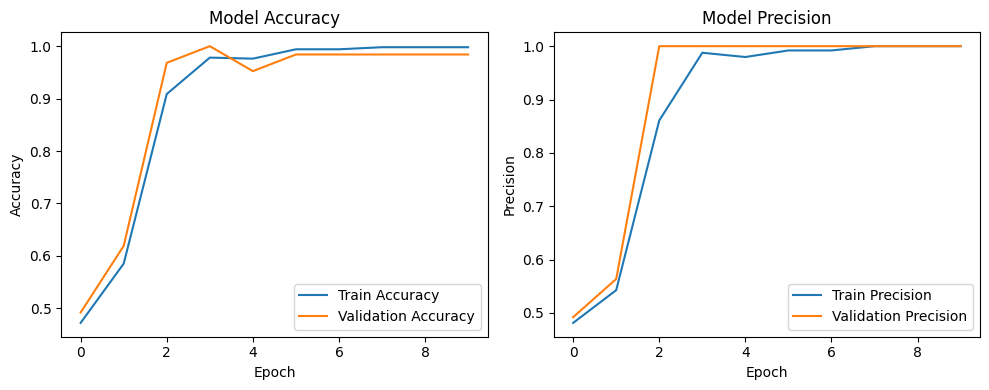

```python
# Accuracy plot
plt.figure(figsize=(10, 4))

plt.subplot(1, 2, 1)
plt.plot(history_1.history['accuracy'], label='Train Accuracy')
plt.plot(history_1.history['val_accuracy'], label='Validation Accuracy')
plt.title('Model Accuracy')
plt.xlabel('Epoch')
plt.ylabel('Accuracy')
plt.legend(loc='lower right')

# Precision plot
plt.subplot(1, 2, 2)
plt.plot(history_1.history['Precision'], label='Train Precision')
plt.plot(history_1.history['val_Precision'], label='Validation Precision')
plt.title('Model Precision')
plt.xlabel('Epoch')
plt.ylabel('Precision')
plt.legend(loc='lower right')

plt.tight_layout()
plt.show()
```

```python
model_1_train_perf = model_performance_classification(model_1, X_train_normalized,y_train)

print("Train performance metrics")
print(model_1_train_perf)
```

```
16/16 ━━━━━━━━━━━━━━━━━━━━ 0s 19ms/step
Train performance metrics
   Accuracy    Recall  Precision  F1 Score
0  0.992063  0.992063   0.992186  0.992062
```

```
16/16 ━━━━━━━━━━━━━━━━━━━━ 0s 11ms/step
```

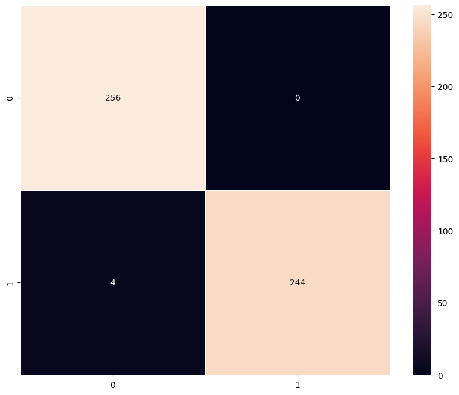

```python
plot_confusion_matrix(model_1,X_train_normalized,y_train)
```

```python
model_1_valid_perf = model_performance_classification(model_1, X_val_normalized,y_val)

print("Validation performance metrics")
print(model_1_valid_perf)
```

```
2/2 ━━━━━━━━━━━━━━━━━━━━ 0s 23ms/step
Validation performance metrics
   Accuracy    Recall  Precision  F1 Score
0  0.984127  0.984127   0.984608  0.984119
```

```
2/2 ━━━━━━━━━━━━━━━━━━━━ 0s 22ms/step
```

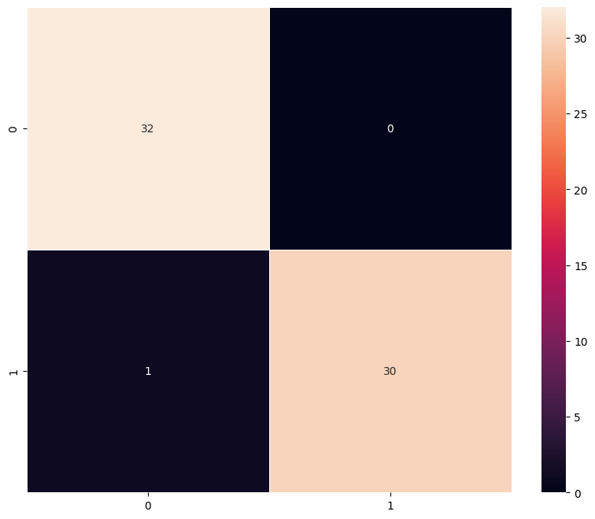

```python
plot_confusion_matrix(model_1,X_val_normalized,y_val)
```

**Observations:**

- We can see from the above plot that **the model has perfomed well on train and validation data.**

### Vizualizing the predictions

```python
# Index of the sample to visualize and predict
index = 2

# Show the image
plt.figure(figsize=(2, 2))
plt.imshow(X_val[index])
plt.axis('off')
plt.show()

# Predict the label
prediction = model_1.predict(X_val_normalized[index].reshape(1, 200, 200, 3))
predicted_label = int(prediction[0][0] > 0.5)  # Convert to 0 or 1
print('Predicted Label:', predicted_label)

# Show the true label
true_label = y_val.iloc[index]
print('True Label:', true_label)
```

[output not shown]

```
1/1 ━━━━━━━━━━━━━━━━━━━━ 0s 354ms/step
Predicted Label: 0
True Label: Label    0
Name: 603, dtype: int64
```

```python
3# Index of the sample to visualize and predict (wrongly predicted)
index = 41

# Show the image
plt.figure(figsize=(2, 2))
plt.imshow(X_val[index])
plt.axis('off')
plt.show()

# Predict the label
prediction = model_1.predict(X_val_normalized[index].reshape(1, 200, 200, 3))
predicted_label = int(prediction[0][0] > 0.5)  # Convert to 0 or 1
print('Predicted Label:', predicted_label)

# Show the true label
true_label = y_val.iloc[index]
print('True Label:', true_label)
```

[output not shown]

```
1/1 ━━━━━━━━━━━━━━━━━━━━ 0s 40ms/step
Predicted Label: 0
True Label: Label    1
Name: 113, dtype: int64
```

```python
# Index of the sample to visualize and predict
index = 62

# Show the image
plt.figure(figsize=(2, 2))
plt.imshow(X_val[index])
plt.axis('off')
plt.show()

# Predict the label
prediction = model_1.predict(X_val_normalized[index].reshape(1, 200, 200, 3))
predicted_label = int(prediction[0][0] > 0.5)  # Convert to 0 or 1
print('Predicted Label:', predicted_label)

# Show the true label
true_label = y_val.iloc[index]
print('True Label:', true_label)
```

[output not shown]

```
1/1 ━━━━━━━━━━━━━━━━━━━━ 0s 30ms/step
Predicted Label: 1
True Label: Label    1
Name: 173, dtype: int64
```

**Observations:** From the above 3 results comparing the CNN model (model1) predictions to the actual results we can observe that the model Precision is ~98%. Below are the scenarios

1. Index 2 - shows model predictions as 0 (Without Helmet) and the actual results show 0 (Without Helmet)
2. Index 41 - shows model predictions as 0 (Without Helmet) and the actual results show 1 (with Helmet)
3. Index 62 - shows model predictions as 1 (With Helmet) and the actual results show 1 (with Helmet)

## Model 2: (VGG-16 (Base))

- We will be loading a pre-built architecture - **VGG16**, which was trained on the ImageNet dataset and is the runner-up in the ImageNet competition in 2014.
- For training VGG16, we will directly use the convolutional and pooling layers and freeze their weights i.e. no training will be done on them. For classification, we will add a Flatten and a single dense layer.

```python
vgg_model = VGG16(weights='imagenet', include_top=False, input_shape=(200, 200, 3))
vgg_model.summary()
```

```
Model: "vgg16"
```

```
┏━━━━━━━━━━━━━━━━━━━━━━━━━━━━━━━━━┳━━━━━━━━━━━━━━━━━━━━━━━━┳━━━━━━━━━━━━━━━┓
┃ Layer (type)                    ┃ Output Shape           ┃       Param # ┃
┡━━━━━━━━━━━━━━━━━━━━━━━━━━━━━━━━━╇━━━━━━━━━━━━━━━━━━━━━━━━╇━━━━━━━━━━━━━━━┩
│ input_layer (InputLayer)        │ (None, 200, 200, 3)    │             0 │
├─────────────────────────────────┼────────────────────────┼───────────────┤
│ block1_conv1 (Conv2D)           │ (None, 200, 200, 64)   │         1,792 │
├─────────────────────────────────┼────────────────────────┼───────────────┤
│ block1_conv2 (Conv2D)           │ (None, 200, 200, 64)   │        36,928 │
├─────────────────────────────────┼────────────────────────┼───────────────┤
│ block1_pool (MaxPooling2D)      │ (None, 100, 100, 64)   │             0 │
├─────────────────────────────────┼────────────────────────┼───────────────┤
│ block2_conv1 (Conv2D)           │ (None, 100, 100, 128)  │        73,856 │
├─────────────────────────────────┼────────────────────────┼───────────────┤
│ block2_conv2 (Conv2D)           │ (None, 100, 100, 128)  │       147,584 │
├─────────────────────────────────┼────────────────────────┼───────────────┤
│ block2_pool (MaxPooling2D)      │ (None, 50, 50, 128)    │             0 │
├─────────────────────────────────┼────────────────────────┼───────────────┤
│ block3_conv1 (Conv2D)           │ (None, 50, 50, 256)    │       295,168 │
├─────────────────────────────────┼────────────────────────┼───────────────┤
│ block3_conv2 (Conv2D)           │ (None, 50, 50, 256)    │       590,080 │
├─────────────────────────────────┼────────────────────────┼───────────────┤
│ block3_conv3 (Conv2D)           │ (None, 50, 50, 256)    │       590,080 │
├─────────────────────────────────┼────────────────────────┼───────────────┤
│ block3_pool (MaxPooling2D)      │ (None, 25, 25, 256)    │             0 │
├─────────────────────────────────┼────────────────────────┼───────────────┤
│ block4_conv1 (Conv2D)           │ (None, 25, 25, 512)    │     1,180,160 │
├─────────────────────────────────┼────────────────────────┼───────────────┤
│ block4_conv2 (Conv2D)           │ (None, 25, 25, 512)    │     2,359,808 │
├─────────────────────────────────┼────────────────────────┼───────────────┤
│ block4_conv3 (Conv2D)           │ (None, 25, 25, 512)    │     2,359,808 │
├─────────────────────────────────┼────────────────────────┼───────────────┤
│ block4_pool (MaxPooling2D)      │ (None, 12, 12, 512)    │             0 │
├─────────────────────────────────┼────────────────────────┼───────────────┤
│ block5_conv1 (Conv2D)           │ (None, 12, 12, 512)    │     2,359,808 │
├─────────────────────────────────┼────────────────────────┼───────────────┤
│ block5_conv2 (Conv2D)           │ (None, 12, 12, 512)    │     2,359,808 │
├─────────────────────────────────┼────────────────────────┼───────────────┤
│ block5_conv3 (Conv2D)           │ (None, 12, 12, 512)    │     2,359,808 │
├─────────────────────────────────┼────────────────────────┼───────────────┤
│ block5_pool (MaxPooling2D)      │ (None, 6, 6, 512)      │             0 │
└─────────────────────────────────┴────────────────────────┴───────────────┘
```

```
 Total params: 14,714,688 (56.13 MB)
```

```
 Trainable params: 14,714,688 (56.13 MB)
```

```
 Non-trainable params: 0 (0.00 B)
```

```python
# Making all the layers of the VGG model non-trainable. i.e. freezing them
for layer in vgg_model.layers:
    layer.trainable = False
```

```python
model_2 = Sequential()

# Adding the convolutional part of the VGG16 model from above
model_2.add(vgg_model)

# Flattening the output of the VGG16 model because it is from a convolutional layer
model_2.add(Flatten())

# Adding a dense output layer
model_2.add(Dense(1, activation='sigmoid')) # sigmoid as it is a binary classification
```

```python
opt=Adam(learning_rate=0.001)
model_2.compile(optimizer=opt, loss=keras.losses.BinaryCrossentropy(), metrics=["accuracy","Precision"])
```

```python
# Generating the summary of the model
model_2.summary()
```

```
Model: "sequential"
```

```
┏━━━━━━━━━━━━━━━━━━━━━━━━━━━━━━━━━┳━━━━━━━━━━━━━━━━━━━━━━━━┳━━━━━━━━━━━━━━━┓
┃ Layer (type)                    ┃ Output Shape           ┃       Param # ┃
┡━━━━━━━━━━━━━━━━━━━━━━━━━━━━━━━━━╇━━━━━━━━━━━━━━━━━━━━━━━━╇━━━━━━━━━━━━━━━┩
│ vgg16 (Functional)              │ (None, 6, 6, 512)      │    14,714,688 │
├─────────────────────────────────┼────────────────────────┼───────────────┤
│ flatten (Flatten)               │ (None, 18432)          │             0 │
├─────────────────────────────────┼────────────────────────┼───────────────┤
│ dense (Dense)                   │ (None, 1)              │        18,433 │
└─────────────────────────────────┴────────────────────────┴───────────────┘
```

```
 Total params: 14,733,121 (56.20 MB)
```

```
 Trainable params: 18,433 (72.00 KB)
```

```
 Non-trainable params: 14,714,688 (56.13 MB)
```

```python
train_datagen = ImageDataGenerator()
```

```python
# Epochs
epochs = 10
# Batch size
batch_size = 8

history_2 = model_2.fit(train_datagen.flow(X_train_normalized,y_train,
                                      batch_size=batch_size,
                                      seed=42,
                                      shuffle=False),
                    epochs=epochs,
                    steps_per_epoch=X_train_normalized.shape[0] // batch_size,
                    validation_data=(X_val_normalized,y_val),
                    verbose=1)
```

```
63/63 ━━━━━━━━━━━━━━━━━━━━ 29s 378ms/step - Precision: 0.8623 - accuracy: 0.8735 - loss: 0.2500 - val_Precision: 1.0000 - val_accuracy: 1.0000 - val_loss: 0.0047
63/63 ━━━━━━━━━━━━━━━━━━━━ 3s 48ms/step - Precision: 1.0000 - accuracy: 1.0000 - loss: 0.0032 - val_Precision: 1.0000 - val_accuracy: 1.0000 - val_loss: 0.0029
63/63 ━━━━━━━━━━━━━━━━━━━━ 3s 47ms/step - Precision: 1.0000 - accuracy: 1.0000 - loss: 0.0023 - val_Precision: 1.0000 - val_accuracy: 1.0000 - val_loss: 0.0023
63/63 ━━━━━━━━━━━━━━━━━━━━ 3s 53ms/step - Precision: 1.0000 - accuracy: 1.0000 - loss: 0.0018 - val_Precision: 1.0000 - val_accuracy: 1.0000 - val_loss: 0.0019
63/63 ━━━━━━━━━━━━━━━━━━━━ 5s 49ms/step - Precision: 1.0000 - accuracy: 1.0000 - loss: 0.0012 - val_Precision: 1.0000 - val_accuracy: 1.0000 - val_loss: 0.0016
63/63 ━━━━━━━━━━━━━━━━━━━━ 5s 49ms/step - Precision: 1.0000 - accuracy: 1.0000 - loss: 7.8622e-04 - val_Precision: 1.0000 - val_accuracy: 1.0000 - val_loss: 0.0013
63/63 ━━━━━━━━━━━━━━━━━━━━ 5s 49ms/step - Precision: 1.0000 - accuracy: 1.0000 - loss: 7.6496e-04 - val_Precision: 1.0000 - val_accuracy: 1.0000 - val_loss: 0.0011
63/63 ━━━━━━━━━━━━━━━━━━━━ 5s 49ms/step - Precision: 1.0000 - accuracy: 1.0000 - loss: 6.0582e-04 - val_Precision: 1.0000 - val_accuracy: 1.0000 - val_loss: 0.0010
63/63 ━━━━━━━━━━━━━━━━━━━━ 5s 50ms/step - Precision: 1.0000 - accuracy: 1.0000 - loss: 4.1044e-04 - val_Precision: 1.0000 - val_accuracy: 1.0000 - val_loss: 9.1401e-04
63/63 ━━━━━━━━━━━━━━━━━━━━ 3s 53ms/step - Precision: 1.0000 - accuracy: 1.0000 - loss: 4.4281e-04 - val_Precision: 1.0000 - val_accuracy: 1.0000 - val_loss: 8.1205e-04
```

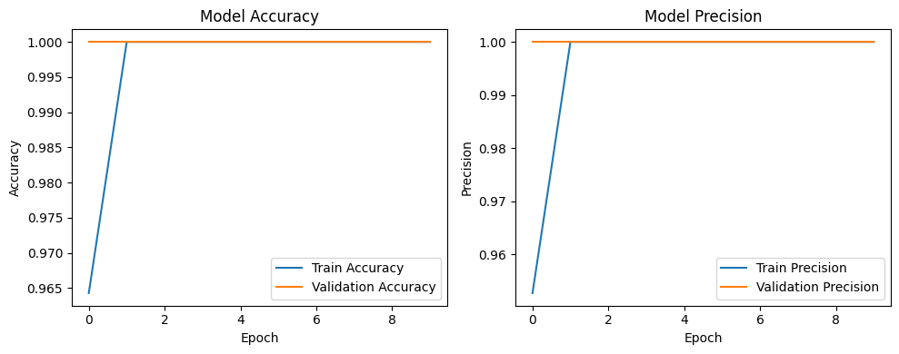

```python
# Accuracy plot
plt.figure(figsize=(10, 4))

plt.subplot(1, 2, 1)
plt.plot(history_2.history['accuracy'], label='Train Accuracy')
plt.plot(history_2.history['val_accuracy'], label='Validation Accuracy')
plt.title('Model Accuracy')
plt.xlabel('Epoch')
plt.ylabel('Accuracy')
plt.legend(loc='lower right')

# Precision plot
plt.subplot(1, 2, 2)
plt.plot(history_2.history['Precision'], label='Train Precision')
plt.plot(history_2.history['val_Precision'], label='Validation Precision')
plt.title('Model Precision')
plt.xlabel('Epoch')
plt.ylabel('Precision')
plt.legend(loc='lower right')

plt.tight_layout()
plt.show()
```

```python
model_2_train_perf = model_performance_classification(model_2,X_train_normalized,y_train)

print("Train performance metrics")
print(model_2_train_perf)
```

```
16/16 ━━━━━━━━━━━━━━━━━━━━ 11s 675ms/step
Train performance metrics
   Accuracy  Recall  Precision  F1 Score
0       1.0     1.0        1.0       1.0
```

```python
plot_confusion_matrix(model_2,X_train_normalized,y_train)
```

[output not shown]

```
16/16 ━━━━━━━━━━━━━━━━━━━━ 2s 146ms/step
```

```python
model_2_valid_perf = model_performance_classification(model_2, X_val_normalized,y_val)

print("Validation performance metrics")
print(model_2_valid_perf)
```

```
2/2 ━━━━━━━━━━━━━━━━━━━━ 1s 474ms/step
Validation performance metrics
   Accuracy  Recall  Precision  F1 Score
0       1.0     1.0        1.0       1.0
```

```python
plot_confusion_matrix(model_2,X_val_normalized,y_val)
```

[output not shown]

```
2/2 ━━━━━━━━━━━━━━━━━━━━ 0s 177ms/step
```

### Visualizing the prediction:

```python
# Index of the sample to visualize and predict
index = 2

# Show the image
plt.figure(figsize=(2, 2))
plt.imshow(X_val[index])
plt.axis('off')
plt.show()

# Predict the label
prediction = model_2.predict(X_val_normalized[index].reshape(1, 200, 200, 3))
predicted_label = int(prediction[0][0] > 0.5)  # Convert to 0 or 1
print('Predicted Label:', predicted_label)

# Show the true label
true_label = y_val.iloc[index]
print('True Label:', true_label)
```

[output not shown]

```
1/1 ━━━━━━━━━━━━━━━━━━━━ 0s 56ms/step
Predicted Label: 0
True Label: Label    0
Name: 603, dtype: int64
```

```python
# Index of the sample to visualize and predict
index = 41

# Show the image
plt.figure(figsize=(2, 2))
plt.imshow(X_val[index])
plt.axis('off')
plt.show()

# Predict the label
prediction = model_2.predict(X_val_normalized[index].reshape(1, 200, 200, 3))
predicted_label = int(prediction[0][0] > 0.5)  # Convert to 0 or 1
print('Predicted Label:', predicted_label)

# Show the true label
true_label = y_val.iloc[index]
print('True Label:', true_label)
```

[output not shown]

```
1/1 ━━━━━━━━━━━━━━━━━━━━ 0s 40ms/step
Predicted Label: 1
True Label: Label    1
Name: 113, dtype: int64
```

```python
# Index of the sample to visualize and predict
index = 62

# Show the image
plt.figure(figsize=(2, 2))
plt.imshow(X_val[index])
plt.axis('off')
plt.show()

# Predict the label
prediction = model_2.predict(X_val_normalized[index].reshape(1, 200, 200, 3))
predicted_label = int(prediction[0][0] > 0.5)  # Convert to 0 or 1
print('Predicted Label:', predicted_label)

# Show the true label
true_label = y_val.iloc[index]
print('True Label:', true_label)
```

[output not shown]

```
1/1 ━━━━━━━━━━━━━━━━━━━━ 0s 68ms/step
Predicted Label: 1
True Label: Label    1
Name: 173, dtype: int64
```

**Observations:** From the above 3 results comparing the VGG-16 base model (model2) predictions to the actual results we can observe that the model accuracy is ~100% correct. Below are the scenarios

1. Index 2 - shows model predictions as 0 (Without Helmet) and the actual results show 0 (without Helmet)
2. Index 41 - shows model predictions as 1 (With Helmet) and the actual results show 1 (with Helmet)
3. Index 62 - shows model predictions as 1 (With Helmet) and the actual results show 1 (with Helmet)

## Model 3: (VGG-16 (Base + FFNN))

- We will directly use the convolutional and pooling layers and freeze their weights i.e. no training will be done on them. For classification, we will add a Flatten layer and a Feed Forward Neural Network.

```python
model_3 = Sequential()

# Adding the convolutional part of the VGG16 model from above
model_3.add(vgg_model)

# Flattening the output of the VGG16 model because it is from a convolutional layer
model_3.add(Flatten())

# Adding the Feed Forward neural network
model_3.add(Dense(256,activation='relu'))
model_3.add(Dropout(rate=0.4))
model_3.add(Dense(32,activation='relu'))

# Adding a dense output layer
model_3.add(Dense(1,activation='sigmoid'))
```

```python
opt = Adam(learning_rate=0.001)
```

```python
# Compile model
model_3.compile(optimizer=opt,loss=keras.losses.BinaryCrossentropy(), metrics=["accuracy","Precision"])
```

```python
# Generating the summary of the model
model_3.summary()
```

```
Model: "sequential"
```

```
┏━━━━━━━━━━━━━━━━━━━━━━━━━━━━━━━━━┳━━━━━━━━━━━━━━━━━━━━━━━━┳━━━━━━━━━━━━━━━┓
┃ Layer (type)                    ┃ Output Shape           ┃       Param # ┃
┡━━━━━━━━━━━━━━━━━━━━━━━━━━━━━━━━━╇━━━━━━━━━━━━━━━━━━━━━━━━╇━━━━━━━━━━━━━━━┩
│ vgg16 (Functional)              │ (None, 6, 6, 512)      │    14,714,688 │
├─────────────────────────────────┼────────────────────────┼───────────────┤
│ flatten (Flatten)               │ (None, 18432)          │             0 │
├─────────────────────────────────┼────────────────────────┼───────────────┤
│ dense (Dense)                   │ (None, 256)            │     4,718,848 │
├─────────────────────────────────┼────────────────────────┼───────────────┤
│ dropout (Dropout)               │ (None, 256)            │             0 │
├─────────────────────────────────┼────────────────────────┼───────────────┤
│ dense_1 (Dense)                 │ (None, 32)             │         8,224 │
├─────────────────────────────────┼────────────────────────┼───────────────┤
│ dense_2 (Dense)                 │ (None, 1)              │            33 │
└─────────────────────────────────┴────────────────────────┴───────────────┘
```

```
 Total params: 19,441,793 (74.16 MB)
```

```
 Trainable params: 4,727,105 (18.03 MB)
```

```
 Non-trainable params: 14,714,688 (56.13 MB)
```

```python
history_3 = model_3.fit(train_datagen.flow(X_train_normalized,y_train,
                                       batch_size=8,
                                       seed=42,
                                       shuffle=False),
                    epochs=10,
                    steps_per_epoch=X_train_normalized.shape[0] // batch_size,
                    validation_data=(X_val_normalized,y_val),
                    verbose=1)
```

```
63/63 ━━━━━━━━━━━━━━━━━━━━ 8s 87ms/step - Precision: 0.7947 - accuracy: 0.8216 - loss: 0.4438 - val_Precision: 1.0000 - val_accuracy: 1.0000 - val_loss: 4.6252e-05
63/63 ━━━━━━━━━━━━━━━━━━━━ 7s 49ms/step - Precision: 1.0000 - accuracy: 1.0000 - loss: 0.0010 - val_Precision: 1.0000 - val_accuracy: 1.0000 - val_loss: 6.9654e-05
63/63 ━━━━━━━━━━━━━━━━━━━━ 5s 49ms/step - Precision: 0.9943 - accuracy: 0.9972 - loss: 0.0065 - val_Precision: 1.0000 - val_accuracy: 1.0000 - val_loss: 1.4586e-05
63/63 ━━━━━━━━━━━━━━━━━━━━ 3s 48ms/step - Precision: 1.0000 - accuracy: 0.9985 - loss: 0.0040 - val_Precision: 1.0000 - val_accuracy: 1.0000 - val_loss: 4.4611e-05
63/63 ━━━━━━━━━━━━━━━━━━━━ 5s 49ms/step - Precision: 0.9990 - accuracy: 0.9995 - loss: 0.0020 - val_Precision: 1.0000 - val_accuracy: 1.0000 - val_loss: 1.6027e-04
63/63 ━━━━━━━━━━━━━━━━━━━━ 5s 51ms/step - Precision: 1.0000 - accuracy: 1.0000 - loss: 2.8599e-04 - val_Precision: 1.0000 - val_accuracy: 1.0000 - val_loss: 1.7128e-05
63/63 ━━━━━━━━━━━━━━━━━━━━ 5s 49ms/step - Precision: 1.0000 - accuracy: 1.0000 - loss: 4.3690e-04 - val_Precision: 1.0000 - val_accuracy: 1.0000 - val_loss: 1.2350e-05
63/63 ━━━━━━━━━━━━━━━━━━━━ 5s 50ms/step - Precision: 1.0000 - accuracy: 1.0000 - loss: 1.1875e-04 - val_Precision: 1.0000 - val_accuracy: 1.0000 - val_loss: 2.0952e-05
63/63 ━━━━━━━━━━━━━━━━━━━━ 5s 49ms/step - Precision: 1.0000 - accuracy: 1.0000 - loss: 8.6577e-05 - val_Precision: 1.0000 - val_accuracy: 1.0000 - val_loss: 1.0963e-05
63/63 ━━━━━━━━━━━━━━━━━━━━ 5s 55ms/step - Precision: 1.0000 - accuracy: 1.0000 - loss: 2.5094e-05 - val_Precision: 1.0000 - val_accuracy: 1.0000 - val_loss: 7.3652e-06
```

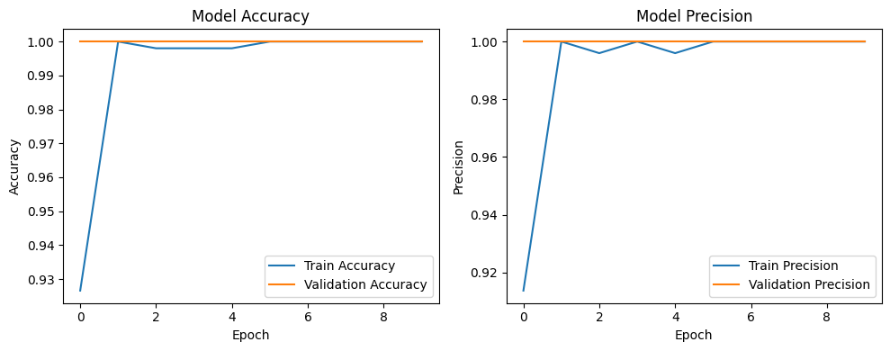

```python
# Accuracy plot
plt.figure(figsize=(10, 4))

plt.subplot(1, 2, 1)
plt.plot(history_3.history['accuracy'], label='Train Accuracy')
plt.plot(history_3.history['val_accuracy'], label='Validation Accuracy')
plt.title('Model Accuracy')
plt.xlabel('Epoch')
plt.ylabel('Accuracy')
plt.legend(loc='lower right')

# Precision plot
plt.subplot(1, 2, 2)
plt.plot(history_3.history['Precision'], label='Train Precision')
plt.plot(history_3.history['val_Precision'], label='Validation Precision')
plt.title('Model Precision')
plt.xlabel('Epoch')
plt.ylabel('Precision')
plt.legend(loc='lower right')

plt.tight_layout()
plt.show()
```

```python
model_3_train_perf = model_performance_classification(model_3, X_train_normalized,y_train)

print("Train performance metrics")
print(model_3_train_perf)
```

```
16/16 ━━━━━━━━━━━━━━━━━━━━ 4s 209ms/step
Train performance metrics
   Accuracy  Recall  Precision  F1 Score
0       1.0     1.0        1.0       1.0
```

```python
plot_confusion_matrix(model_3,X_train_normalized,y_train)
```

[output not shown]

```
16/16 ━━━━━━━━━━━━━━━━━━━━ 2s 148ms/step
```

```python
model_3_valid_perf = model_performance_classification(model_3, X_val_normalized,y_val)

print("Validation performance metrics")
print(model_3_valid_perf)
```

```
2/2 ━━━━━━━━━━━━━━━━━━━━ 1s 491ms/step
Validation performance metrics
   Accuracy  Recall  Precision  F1 Score
0       1.0     1.0        1.0       1.0
```

```python
plot_confusion_matrix(model_3,X_val_normalized,y_val)
```

[output not shown]

```
2/2 ━━━━━━━━━━━━━━━━━━━━ 0s 161ms/step
```

#### Visualizing the predictions

```python
# Index of the sample to visualize and predict
index = 2

# Show the image
plt.figure(figsize=(2, 2))
plt.imshow(X_val[index])
plt.axis('off')
plt.show()

# Predict the label
prediction = model_3.predict(X_val_normalized[index].reshape(1, 200, 200, 3))
predicted_label = int(prediction[0][0] > 0.5)  # Convert to 0 or 1
print('Predicted Label:', predicted_label)

# Show the true label
true_label = y_val.iloc[index]
print('True Label:', true_label)
```

[output not shown]

```
1/1 ━━━━━━━━━━━━━━━━━━━━ 0s 61ms/step
Predicted Label: 0
True Label: Label    0
Name: 603, dtype: int64
```

```python
# Index of the sample to visualize and predict
index = 41

# Show the image
plt.figure(figsize=(2, 2))
plt.imshow(X_val[index])
plt.axis('off')
plt.show()

# Predict the label
prediction = model_3.predict(X_val_normalized[index].reshape(1, 200, 200, 3))
predicted_label = int(prediction[0][0] > 0.5)  # Convert to 0 or 1
print('Predicted Label:', predicted_label)

# Show the true label
true_label = y_val.iloc[index]
print('True Label:', true_label)
```

[output not shown]

```
1/1 ━━━━━━━━━━━━━━━━━━━━ 0s 40ms/step
Predicted Label: 1
True Label: Label    1
Name: 113, dtype: int64
```

```python
# Index of the sample to visualize and predict
index = 62

# Show the image
plt.figure(figsize=(2, 2))
plt.imshow(X_val[index])
plt.axis('off')
plt.show()

# Predict the label
prediction = model_3.predict(X_val_normalized[index].reshape(1, 200, 200, 3))
predicted_label = int(prediction[0][0] > 0.5)  # Convert to 0 or 1
print('Predicted Label:', predicted_label)

# Show the true label
true_label = y_val.iloc[index]
print('True Label:', true_label)
```

[output not shown]

```
1/1 ━━━━━━━━━━━━━━━━━━━━ 0s 134ms/step
Predicted Label: 1
True Label: Label    1
Name: 173, dtype: int64
```

## Model 4: (VGG-16 (Base + FFNN + Data Augmentation)

- In most of the real-world case studies, it is challenging to acquire a large number of images and then train CNNs.
- To overcome this problem, one approach we might consider is **Data Augmentation**.
- CNNs have the property of **translational invariance**, which means they can recognise an object even if its appearance shifts translationally in some way. - Taking this attribute into account, we can augment the images using the techniques listed below
  - Horizontal Flip (should be set to True/False)
  - Vertical Flip (should be set to True/False)
  - Height Shift (should be between 0 and 1)
  - Width Shift (should be between 0 and 1)
  - Rotation (should be between 0 and 180)
  - Shear (should be between 0 and 1)
  - Zoom (should be between 0 and 1) etc.

Remember, **data augmentation should not be used in the validation/test data set**.

```python
model_4 = Sequential()

# Adding the convolutional part of the VGG16 model from above
model_4.add(vgg_model)

# Flattening the output of the VGG16 model because it is from a convolutional layer
model_4.add(Flatten())

# Adding the Feed Forward neural network
model_4.add(Dense(256,activation='relu'))
model_4.add(Dropout(rate=0.4))
model_4.add(Dense(32,activation='relu'))

# Adding a dense output layer
model_4.add(Dense(1,activation='sigmoid'))
```

```python
opt=Adam(learning_rate= 0.001)
# Compile model
model_4.compile(optimizer=opt,loss=keras.losses.BinaryCrossentropy(), metrics=["accuracy","Precision"])
```

```python
# Generating the summary of the model
model_4.summary()
```

```
Model: "sequential_1"
```

```
┏━━━━━━━━━━━━━━━━━━━━━━━━━━━━━━━━━┳━━━━━━━━━━━━━━━━━━━━━━━━┳━━━━━━━━━━━━━━━┓
┃ Layer (type)                    ┃ Output Shape           ┃       Param # ┃
┡━━━━━━━━━━━━━━━━━━━━━━━━━━━━━━━━━╇━━━━━━━━━━━━━━━━━━━━━━━━╇━━━━━━━━━━━━━━━┩
│ vgg16 (Functional)              │ (None, 6, 6, 512)      │    14,714,688 │
├─────────────────────────────────┼────────────────────────┼───────────────┤
│ flatten_1 (Flatten)             │ (None, 18432)          │             0 │
├─────────────────────────────────┼────────────────────────┼───────────────┤
│ dense_3 (Dense)                 │ (None, 256)            │     4,718,848 │
├─────────────────────────────────┼────────────────────────┼───────────────┤
│ dropout_1 (Dropout)             │ (None, 256)            │             0 │
├─────────────────────────────────┼────────────────────────┼───────────────┤
│ dense_4 (Dense)                 │ (None, 32)             │         8,224 │
├─────────────────────────────────┼────────────────────────┼───────────────┤
│ dense_5 (Dense)                 │ (None, 1)              │            33 │
└─────────────────────────────────┴────────────────────────┴───────────────┘
```

```
 Total params: 19,441,793 (74.16 MB)
```

```
 Trainable params: 4,727,105 (18.03 MB)
```

```
 Non-trainable params: 14,714,688 (56.13 MB)
```

```python
# Applying data augmentation
train_datagen = ImageDataGenerator(
                              rotation_range=20,
                              fill_mode='nearest',width_shift_range=0.2,height_shift_range=0.2,shear_range=0.3,zoom_range=0.4
                             )
```

```python
history_4 = model_4.fit(train_datagen.flow(X_train_normalized,y_train,
                                       batch_size=8,
                                       seed=42,
                                       shuffle=False),
                    epochs=epochs,
                    steps_per_epoch=X_train_normalized.shape[0] // batch_size,
                    validation_data=(X_val_normalized,y_val),
                    verbose=1)
```

```
63/63 ━━━━━━━━━━━━━━━━━━━━ 11s 125ms/step - Precision: 0.8282 - accuracy: 0.8213 - loss: 0.3874 - val_Precision: 1.0000 - val_accuracy: 1.0000 - val_loss: 3.9819e-05
63/63 ━━━━━━━━━━━━━━━━━━━━ 12s 176ms/step - Precision: 0.9813 - accuracy: 0.9788 - loss: 0.0466 - val_Precision: 1.0000 - val_accuracy: 1.0000 - val_loss: 5.5212e-07
63/63 ━━━━━━━━━━━━━━━━━━━━ 9s 139ms/step - Precision: 0.9948 - accuracy: 0.9930 - loss: 0.0191 - val_Precision: 1.0000 - val_accuracy: 1.0000 - val_loss: 1.5674e-05
63/63 ━━━━━━━━━━━━━━━━━━━━ 10s 130ms/step - Precision: 0.9958 - accuracy: 0.9888 - loss: 0.0225 - val_Precision: 1.0000 - val_accuracy: 1.0000 - val_loss: 1.9476e-06
63/63 ━━━━━━━━━━━━━━━━━━━━ 8s 89ms/step - Precision: 0.9893 - accuracy: 0.9932 - loss: 0.0161 - val_Precision: 1.0000 - val_accuracy: 1.0000 - val_loss: 0.0033
63/63 ━━━━━━━━━━━━━━━━━━━━ 10s 83ms/step - Precision: 0.9754 - accuracy: 0.9832 - loss: 0.0676 - val_Precision: 1.0000 - val_accuracy: 1.0000 - val_loss: 8.3013e-06
63/63 ━━━━━━━━━━━━━━━━━━━━ 7s 107ms/step - Precision: 0.9849 - accuracy: 0.9880 - loss: 0.0508 - val_Precision: 1.0000 - val_accuracy: 1.0000 - val_loss: 5.9122e-06
63/63 ━━━━━━━━━━━━━━━━━━━━ 9s 87ms/step - Precision: 0.9844 - accuracy: 0.9999 - loss: 0.0031 - val_Precision: 1.0000 - val_accuracy: 1.0000 - val_loss: 2.8764e-07
63/63 ━━━━━━━━━━━━━━━━━━━━ 10s 83ms/step - Precision: 0.9964 - accuracy: 0.9961 - loss: 0.0145 - val_Precision: 1.0000 - val_accuracy: 1.0000 - val_loss: 1.2091e-05
63/63 ━━━━━━━━━━━━━━━━━━━━ 6s 102ms/step - Precision: 0.9892 - accuracy: 0.9893 - loss: 0.0429 - val_Precision: 1.0000 - val_accuracy: 1.0000 - val_loss: 3.2265e-05
```

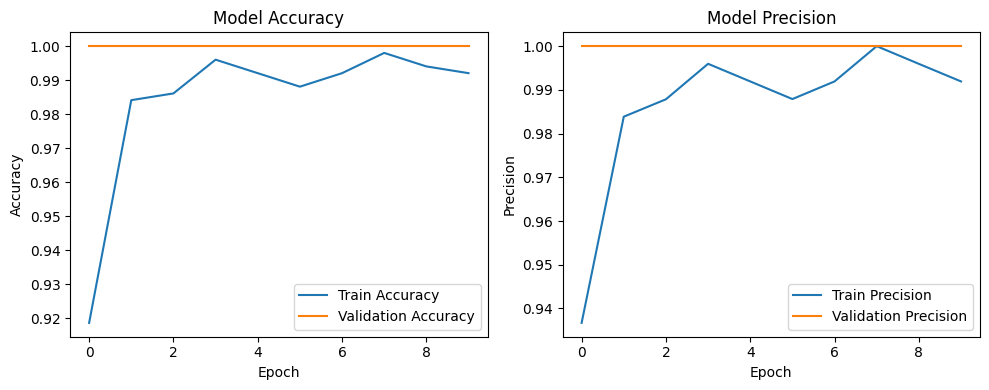

```python
# Accuracy plot
plt.figure(figsize=(10, 4))

plt.subplot(1, 2, 1)
plt.plot(history_4.history['accuracy'], label='Train Accuracy')
plt.plot(history_4.history['val_accuracy'], label='Validation Accuracy')
plt.title('Model Accuracy')
plt.xlabel('Epoch')
plt.ylabel('Accuracy')
plt.legend(loc='lower right')

# Precision plot
plt.subplot(1, 2, 2)
plt.plot(history_4.history['Precision'], label='Train Precision')
plt.plot(history_4.history['val_Precision'], label='Validation Precision')
plt.title('Model Precision')
plt.xlabel('Epoch')
plt.ylabel('Precision')
plt.legend(loc='lower right')

plt.tight_layout()
plt.show()
```

```python
model_4_train_perf = model_performance_classification(model_4, X_train_normalized,y_train)

print("Train performance metrics")
print(model_4_train_perf)
```

```
16/16 ━━━━━━━━━━━━━━━━━━━━ 3s 180ms/step
Train performance metrics
   Accuracy  Recall  Precision  F1 Score
0       1.0     1.0        1.0       1.0
```

```python
plot_confusion_matrix(model_4,X_train_normalized,y_train)
```

[output not shown]

```
16/16 ━━━━━━━━━━━━━━━━━━━━ 2s 152ms/step
```

```python
model_4_valid_perf = model_performance_classification(model_4, X_val_normalized,y_val)

print("Validation performance metrics")
print(model_4_valid_perf)
```

```
2/2 ━━━━━━━━━━━━━━━━━━━━ 1s 450ms/step
Validation performance metrics
   Accuracy  Recall  Precision  F1 Score
0       1.0     1.0        1.0       1.0
```

```python
plot_confusion_matrix(model_4,X_val_normalized,y_val)
```

[output not shown]

```
2/2 ━━━━━━━━━━━━━━━━━━━━ 0s 161ms/step
```